# Lecture 03

February 22, 2016

## Intro Stats Final Exam

Using the `grades.csv` dataset from `Lec02`, we study the difference in mean final scores for

- those with an even # of letters in their last name vs.
- those with an odd #

i.e. the **parameter** of interest is \(\mu_E - \mu_O\)

## Intro Stats Final Exam

**Beware**: the solid line is the median, not the mean.

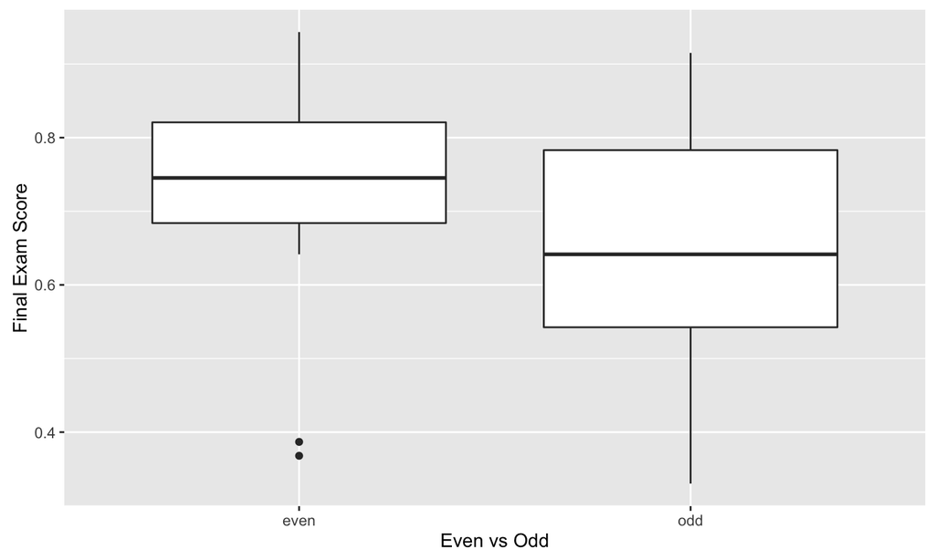

## Permutation Test

To describe the permutation test, we now consider

- only the first 6 rows
- and for illustrative purposes a new variable `row_index`

## Intro Stats Final Exam

| final | even_vs_odd | row_index |
| --- | --- | --- |
| 0.915 | odd | 1 |
| 0.811 | even | 2 |
| 0.906 | even | 3 |
| 0.943 | even | 4 |
| 0.877 | odd | 5 |
| 0.840 | even | 6 |

## Observed Test Statistic

Rows `c(2, 3, 4, 6)` are the students with an even # of letters in their last name.

To compute the **observed test statisitic** i.e. the observed difference in sample means \(\overline{x}_E - \overline{x}_O\) we run

```
index <- c(2, 3, 4, 6)

# mean of evens - mean of odds:
mean(final[index]) - mean(final[-index])
```

## The Crux

Under \(H_0: \mu_E - \mu_O=0\), the two groups have equal mean.

So under \(H_0\) `even_vs_odd` is a meaningless label, hence we can **permute/shuffle** it to no consequence.

## Observed Data

Originally, the evens are `c(2, 3, 4, 6)`

| final | even_vs_odd | row_index |
| --- | --- | --- |
| 0.915 | odd | 1 |
| 0.811 | even | 2 |
| 0.906 | even | 3 |
| 0.943 | even | 4 |
| 0.877 | odd | 5 |
| 0.840 | even | 6 |

## Permuted Data

In this simulation, the evens are `c(1, 2, 3, 5)`

| final | even_vs_odd | row_index |
| --- | --- | --- |
| 0.915 | even | 1 |
| 0.811 | even | 2 |
| 0.906 | even | 3 |
| 0.943 | odd | 4 |
| 0.877 | even | 5 |
| 0.840 | odd | 6 |

## Permuted Data

In this simulation, the evens are `c(1, 2, 3, 5)`

| final | even_vs_odd | row_index |
| --- | --- | --- |
| 0.915 | even | 1 |
| 0.811 | even | 2 |
| 0.906 | even | 3 |
| 0.943 | odd | 4 |
| 0.877 | even | 5 |
| 0.840 | odd | 6 |

## Permuted Data

In this simulation, the evens are `c(1, 3, 4, 6)`

| final | even_vs_odd | row_index |
| --- | --- | --- |
| 0.915 | even | 1 |
| 0.811 | odd | 2 |
| 0.906 | even | 3 |
| 0.943 | even | 4 |
| 0.877 | odd | 5 |
| 0.840 | even | 6 |

## Permuted Data

In this simulation, the evens are `c(1, 3, 4, 5)`

| final | even_vs_odd | row_index |
| --- | --- | --- |
| 0.915 | even | 1 |
| 0.811 | odd | 2 |
| 0.906 | even | 3 |
| 0.943 | even | 4 |
| 0.877 | even | 5 |
| 0.840 | odd | 6 |

## Coding the Permutation

The permuting/shuffling of the `even_vs_odd` label is done by randomly **resampling** which 4 of the 6 rows will be the evens:

```
index <- sample(6, size=4, replace = FALSE)

# Or equivalently:
row_indices <- 1:6
index <- sample(row_indices, size=4, replace = FALSE)
```

We sample **without replacement** b/c we don't want to resample any row more than once.